# Report_Hackaton_DIA1_CorentinAernouts_AnaisDruart

Anais_Druart, Corentin Aernouts

16/12/2020

## Libraries

```r
library(caTools) #logistic regression, to split the data
library(ROCR) # ROC curves
library(gridExtra)
#library(car)
library(randomForest) #for the bagging and random forests
library(gbm) #for the boosting
library(knitr) # engine for dynamic report
library(ggplot2) # Better plots
#library(caret) # to tune our models
#library(dplyr) # To extract dataframe colums (select function)
library(prettydoc) # Better report layout
library(corrplot) #for the relationships matrix
```

## Loading the sets

### First impressions

We download the data and check the types.

```r
training_set=read.csv("C:/Users/anais/Documents/Esilv/S7/Machine Learning/TD/Hackaton/data.csv")
testing_set=read.csv("C:/Users/anais/Documents/Esilv/S7/Machine Learning/TD/Hackaton/test.csv")
kable(training_set[1:5,])
```

| acousticness | danceability | duration_ms | energy | instrumentalness | key | liveness | loudness | mode | speechiness | tempo | time_signature | valence | target | song_title | artist |
| --- | --- | --- | --- | --- | --- | --- | --- | --- | --- | --- | --- | --- | --- | --- | --- |
| 0.0102 | 0.833 | 204600 | 0.434 | 0.021900 | 2 | 0.1650 | -8.795 | 1 | 0.4310 | 150.062 | 4 | 0.286 | 1 | Mask Off | Future |
| 0.1990 | 0.743 | 326933 | 0.359 | 0.006110 | 1 | 0.1370 | -10.401 | 1 | 0.0794 | 160.083 | 4 | 0.588 | 1 | Redbone | Childish Gambino |
| 0.0344 | 0.838 | 185707 | 0.412 | 0.000234 | 2 | 0.1590 | -7.148 | 1 | 0.2890 | 75.044 | 4 | 0.173 | 1 | Xanny Family | Future |
| 0.6040 | 0.494 | 199413 | 0.338 | 0.510000 | 5 | 0.0922 | -15.236 | 1 | 0.0261 | 86.468 | 4 | 0.230 | 1 | Master Of None | Beach House |
| 0.1800 | 0.678 | 392893 | 0.561 | 0.512000 | 5 | 0.4390 | -11.648 | 0 | 0.0694 | 174.004 | 4 | 0.904 | 1 | Parallel Lines | Junior Boys |

```r
kable(testing_set[1:5,])
```

| acousticness | danceability | duration_ms | energy | instrumentalness | key | liveness | loudness | mode | speechiness | tempo | time_signature | valence | song_title | artist |
| --- | --- | --- | --- | --- | --- | --- | --- | --- | --- | --- | --- | --- | --- | --- |
| 0.2240 | 0.752 | 437293 | 0.7670 | 9.31e-01 | 5 | 0.0833 | -8.022 | 0 | 0.0469 | 117.973 | 4 | 0.564 | One Of Us - Original Mix | Iron Galaxy & Sexlife |
| 0.0648 | 0.855 | 310907 | 0.6380 | 0.00e+00 | 9 | 0.1620 | -4.968 | 0 | 0.1430 | 122.967 | 4 | 0.433 | All Day | Kanye West |
| 0.0300 | 0.350 | 313707 | 0.8440 | 0.00e+00 | 1 | 0.1770 | -4.161 | 0 | 0.0438 | 114.640 | 4 | 0.107 | Play by Play | Autre Ne Veut |
| 0.9670 | 0.384 | 206040 | 0.0544 | 9.64e-01 | 0 | 0.1150 | -19.791 | 1 | 0.0485 | 181.262 | 3 | 0.301 | A Hundred Dreams from Now | Ray Bryant |
| 0.0145 | 0.716 | 215253 | 0.9720 | 3.22e-05 | 7 | 0.3170 | -2.302 | 1 | 0.1960 | 110.026 | 4 | 0.566 | Bangarang (feat. Sirah) | Skrillex |

We can see that most of the data is composed of numbers. Only song_title and artist are strings. We will not take them into account for this study.

### Checking errors

Before trying models to predict if the user will like the music (1) or not (0), we will look for any NA value. Indeed, if there is any, it might be an issue. The following table is the total number of NA values per variable, respectively for the training set and the testing set :

```r
colSums(is.na(training_set))
```

```
##     acousticness     danceability      duration_ms           energy
##                0                0                0                0
## instrumentalness              key         liveness         loudness
##                0                0                0                0
##             mode      speechiness            tempo   time_signature
##                0                0                0                0
##          valence           target       song_title           artist
##                0                0                0                0
```

```r
colSums(is.na(testing_set))
```

```
##     acousticness     danceability      duration_ms           energy
##                0                0                0                0
## instrumentalness              key         liveness         loudness
##                0                0                0                0
##             mode      speechiness            tempo   time_signature
##                0                0                0                0
##          valence       song_title           artist
##                0                0                0
```

Gladly, we can see that there are no NA values in the data.

## Exploratory Data Analysis

### Plotting some variables

We tried to plot some variables to have a better idea of how they look.

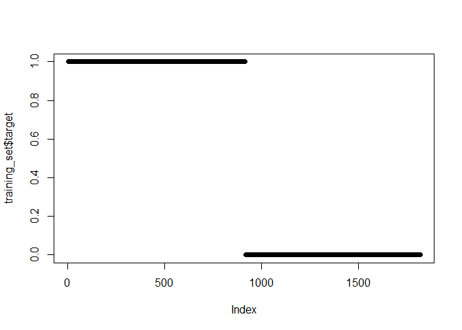

```r
plot(training_set$target)
```

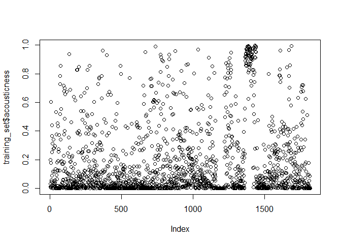

```r
plot(training_set$acousticness)
```

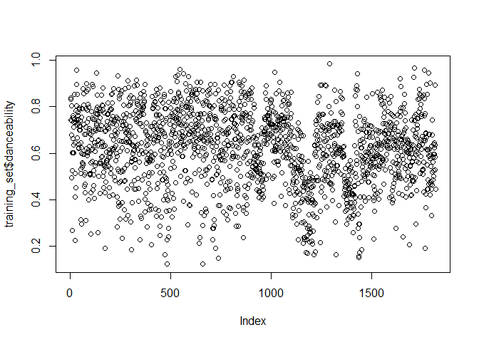

```r
plot(training_set$danceability)
```

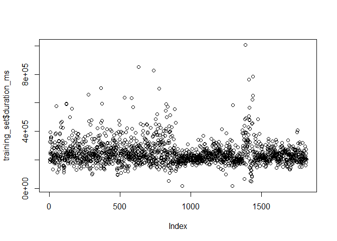

```r
plot(training_set$duration_ms)
```

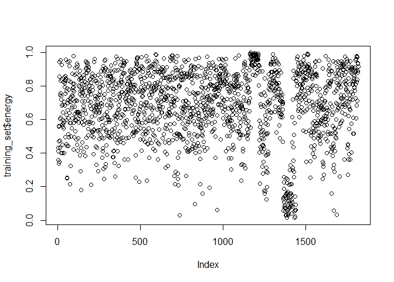

```r
plot(training_set$energy)
```

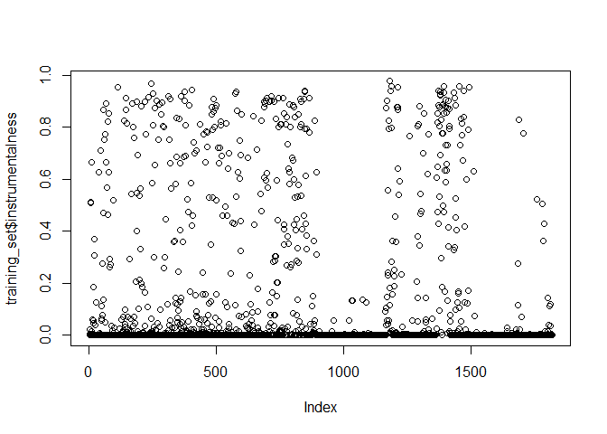

```r
plot(training_set$instrumentalness)
```

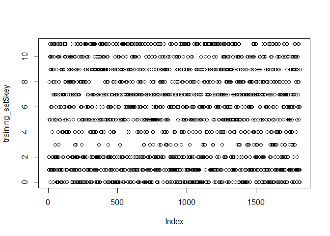

```r
plot(training_set$key)
```

### Boxplotting some relationships

We then tried to boxplot some relashionships, that seemed really strong from our point of view.

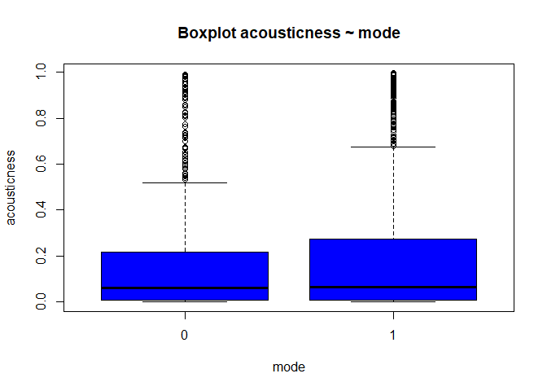

```r
boxplot(acousticness ~ mode, data= training_set, col = "blue", main="Boxplot acousticness ~ mode")
```

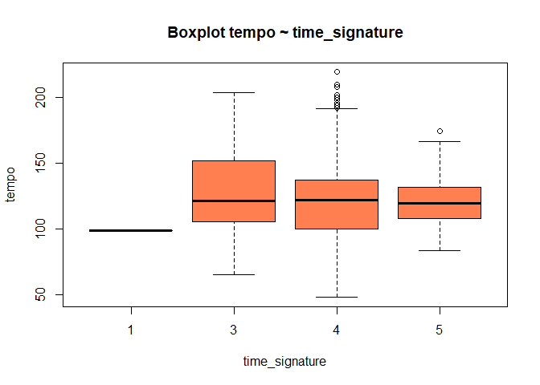

```r
boxplot(tempo ~ time_signature, data= training_set, col = "coral", main="Boxplot tempo ~ time_signature")
```

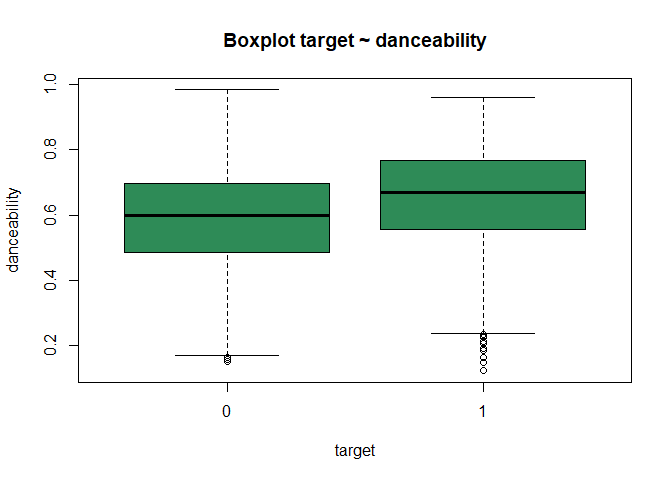

```r
boxplot(danceability ~ target, data = training_set, col = "seagreen", main="Boxplot target ~ danceability")
```

### Checking the relationship between the variables

We then tried to have an overall look at the relationships between all the variables at the same time.

```r
round(cor(training_set[1:14]),2)
```

```
                 acousticness danceability duration_ms energy instrumentalness
acousticness             1.00        -0.19        0.08  -0.64             0.13
danceability            -0.19         1.00       -0.01   0.03            -0.14
duration_ms              0.08        -0.01        1.00  -0.16             0.30
energy                  -0.64         0.03       -0.16   1.00            -0.11
instrumentalness         0.13        -0.14        0.30  -0.11             1.00
key                     -0.06         0.02        0.02   0.07             0.00
liveness                -0.11        -0.15        0.01   0.22             0.01
loudness                -0.56         0.10       -0.28   0.76            -0.34
mode                     0.05        -0.04       -0.07  -0.06            -0.04
speechiness             -0.09         0.15       -0.08   0.09            -0.15
tempo                   -0.13        -0.14       -0.08   0.17             0.00
time_signature          -0.20         0.12       -0.05   0.19            -0.07
valence                 -0.15         0.43       -0.13   0.27            -0.21
target                  -0.12         0.18        0.14   0.02             0.16
                   key liveness loudness  mode speechiness tempo time_signature
acousticness     -0.06    -0.11    -0.56  0.05       -0.09 -0.13          -0.20
danceability      0.02    -0.15     0.10 -0.04        0.15 -0.14           0.12
duration_ms       0.02     0.01    -0.28 -0.07       -0.08 -0.08          -0.05
energy            0.07     0.22     0.76 -0.06        0.09  0.17           0.19
instrumentalness  0.00     0.01    -0.34 -0.04       -0.15  0.00          -0.07
key               1.00     0.05     0.04 -0.20        0.02  0.04           0.04
liveness          0.05     1.00     0.16 -0.02        0.10  0.01           0.02
loudness          0.04     0.16     1.00 -0.03        0.09  0.16           0.14
mode             -0.20    -0.02    -0.03  1.00       -0.04 -0.06          -0.03
speechiness       0.02     0.10     0.09 -0.04        1.00  0.10           0.11
tempo             0.04     0.01     0.16 -0.06        0.10  1.00          -0.05
time_signature    0.04     0.02     0.14 -0.03        0.11 -0.05           1.00
valence           0.02    -0.06     0.19 -0.02        0.05 -0.01           0.14
target            0.02     0.01    -0.09 -0.07        0.16  0.04           0.04
                 valence target
acousticness       -0.15  -0.12
danceability        0.43   0.18
duration_ms        -0.13   0.14
energy              0.27   0.02
instrumentalness   -0.21   0.16
key                 0.02   0.02
liveness           -0.06   0.01
loudness            0.19  -0.09
mode               -0.02  -0.07
speechiness         0.05   0.16
tempo              -0.01   0.04
time_signature      0.14   0.04
valence             1.00   0.11
target              0.11   1.00
```

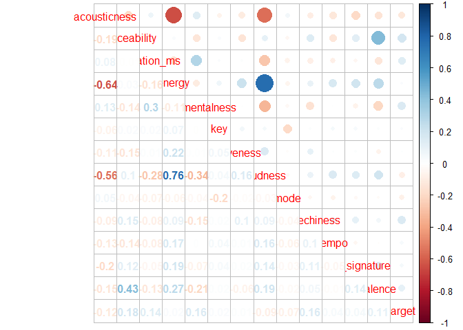

```r
corrplot.mixed(cor(training_set[1:14]))
```

Looking at the relationships, we’re not so sure the logistic regression will give great results.

## Logistic Regression

### Choice of the predictors : backward selection

We used the backward selection to fit our model : We started with all variables in the model.

```r
summary(training_set)
```

```
  acousticness        danceability     duration_ms          energy
 Min.   :0.0000028   Min.   :0.1220   Min.   :  16042   Min.   :0.0148
 1st Qu.:0.0090500   1st Qu.:0.5120   1st Qu.: 199500   1st Qu.:0.5640
 Median :0.0620000   Median :0.6320   Median : 229093   Median :0.7140
 Mean   :0.1847794   Mean   :0.6185   Mean   : 245760   Mean   :0.6827
 3rd Qu.:0.2600000   3rd Qu.:0.7370   3rd Qu.: 270333   3rd Qu.:0.8480
 Max.   :0.9950000   Max.   :0.9840   Max.   :1004627   Max.   :0.9980

 instrumentalness         key            liveness         loudness
 Min.   :0.0000000   Min.   : 0.000   Min.   :0.0219   Min.   :-33.097
 1st Qu.:0.0000000   1st Qu.: 2.000   1st Qu.:0.0923   1st Qu.: -8.372
 Median :0.0000661   Median : 6.000   Median :0.1270   Median : -6.238
 Mean   :0.1315299   Mean   : 5.319   Mean   :0.1927   Mean   : -7.046
 3rd Qu.:0.0510000   3rd Qu.: 9.000   3rd Qu.:0.2510   3rd Qu.: -4.741
 Max.   :0.9760000   Max.   :11.000   Max.   :0.9530   Max.   : -0.307

      mode        speechiness          tempo        time_signature
 Min.   :0.000   Min.   :0.02310   Min.   : 47.86   Min.   :1.000
 1st Qu.:0.000   1st Qu.:0.03750   1st Qu.:100.05   1st Qu.:4.000
 Median :1.000   Median :0.05550   Median :121.92   Median :4.000
 Mean   :0.617   Mean   :0.09272   Mean   :121.55   Mean   :3.968
 3rd Qu.:1.000   3rd Qu.:0.10800   3rd Qu.:137.64   3rd Qu.:4.000
 Max.   :1.000   Max.   :0.62200   Max.   :219.33   Max.   :5.000

    valence           target         song_title               artist
 Min.   :0.0348   Min.   :0.0000   Jack   :   3   Drake          :  12
 1st Qu.:0.2950   1st Qu.:0.0000   River  :   3   Rick Ross      :  12
 Median :0.4930   Median :1.0000   Acamar :   2   Disclosure     :  11
 Mean   :0.4963   Mean   :0.5036   Alright:   2   Backstreet Boys:  10
 3rd Qu.:0.6900   3rd Qu.:1.0000   Annie  :   2   FIDLAR         :   9
 Max.   :0.9750   Max.   :1.0000   Awake  :   2   WALK THE MOON  :   9
                                   (Other):1803   (Other)        :1754
```

```r
summary(aov(target ~ ., data=training_set))
```

```
                   Df Sum Sq Mean Sq F value   Pr(>F)
acousticness        1    6.9   6.924 124.625 1.60e-09 ***
danceability        1   11.8  11.789 212.195 2.10e-11 ***
duration_ms         1    9.8   9.847 177.245 9.32e-11 ***
energy              1    0.6   0.630  11.337 0.003433 **
instrumentalness    1   11.2  11.244 202.391 3.12e-11 ***
key                 1    0.0   0.046   0.821 0.376749
liveness            1    0.4   0.409   7.355 0.014281 *
loudness            1    7.0   6.959 125.256 1.54e-09 ***
mode                1    0.9   0.927  16.692 0.000694 ***
speechiness         1   10.1  10.118 182.132 7.45e-11 ***
tempo               1    1.0   1.010  18.178 0.000467 ***
time_signature      1    0.0   0.004   0.071 0.792272
valence             1    2.5   2.543  45.782 2.44e-06 ***
song_title       1764  389.2   0.221   3.972 0.000591 ***
artist             21    1.5   0.073   1.319 0.278685
Residuals          18    1.0   0.056
---
Signif. codes:  0 '***' 0.001 '**' 0.01 '*' 0.05 '.' 0.1 ' ' 1
```

Then we removed the variable with the largest p-value — that is, the variable that is the least statistically significant.

```r
summary(aov(target ~ (.-time_signature), data=training_set))
```

```
                   Df Sum Sq Mean Sq F value   Pr(>F)
acousticness        1    6.9   6.924 131.549 5.54e-10 ***
danceability        1   11.8  11.789 223.983 5.73e-12 ***
duration_ms         1    9.8   9.847 187.092 2.76e-11 ***
energy              1    0.6   0.630  11.966 0.002627 **
instrumentalness    1   11.2  11.244 213.635 8.67e-12 ***
key                 1    0.0   0.046   0.867 0.363464
liveness            1    0.4   0.409   7.764 0.011768 *
loudness            1    7.0   6.959 132.215 5.31e-10 ***
mode                1    0.9   0.927  17.619 0.000488 ***
speechiness         1   10.1  10.118 192.250 2.18e-11 ***
tempo               1    1.0   1.010  19.188 0.000322 ***
valence             1    2.5   2.547  48.397 1.25e-06 ***
song_title       1764  389.2   0.221   4.192 0.000282 ***
artist             21    1.5   0.074   1.397 0.234113
Residuals          19    1.0   0.053
---
Signif. codes:  0 '***' 0.001 '**' 0.01 '*' 0.05 '.' 0.1 ' ' 1
```

And we continued until a stopping rule we reached p-values equal to less than 0.001.

```r
summary(aov(target ~ (.-time_signature - key), data=training_set))
```

```
                   Df Sum Sq Mean Sq F value   Pr(>F)
acousticness        1    6.9   6.924 138.473 1.92e-10 ***
danceability        1   11.8  11.789 235.772 1.56e-12 ***
duration_ms         1    9.8   9.847 196.939 8.16e-12 ***
energy              1    0.6   0.630  12.596 0.002012 **
instrumentalness    1   11.2  11.244 224.879 2.42e-12 ***
liveness            1    0.4   0.419   8.385 0.008940 **
loudness            1    7.0   6.968 139.360 1.81e-10 ***
mode                1    1.0   0.952  19.046 0.000300 ***
speechiness         1   10.1  10.119 202.371 6.37e-12 ***
tempo               1    1.0   1.008  20.152 0.000224 ***
valence             1    2.5   2.548  50.956 6.47e-07 ***
song_title       1764  389.0   0.221   4.411 0.000132 ***
artist             21    1.7   0.083   1.661 0.130716
Residuals          20    1.0   0.050
---
Signif. codes:  0 '***' 0.001 '**' 0.01 '*' 0.05 '.' 0.1 ' ' 1
```

```r
summary(aov(target ~ (.-time_signature - key - artist), data=training_set))
```

```
                   Df Sum Sq Mean Sq F value   Pr(>F)
acousticness        1    6.9   6.924 103.438 8.91e-13 ***
danceability        1   11.8  11.789 176.119  < 2e-16 ***
duration_ms         1    9.8   9.847 147.112 3.80e-15 ***
energy              1    0.6   0.630   9.409 0.003815 **
instrumentalness    1   11.2  11.244 167.983 4.34e-16 ***
liveness            1    0.4   0.419   6.263 0.016404 *
loudness            1    7.0   6.968 104.100 8.11e-13 ***
mode                1    1.0   0.952  14.227 0.000513 ***
speechiness         1   10.1  10.119 151.170 2.45e-15 ***
tempo               1    1.0   1.008  15.054 0.000371 ***
valence             1    2.5   2.548  38.064 2.48e-07 ***
song_title       1764  389.0   0.221   3.295 5.26e-06 ***
Residuals          41    2.7   0.067
---
Signif. codes:  0 '***' 0.001 '**' 0.01 '*' 0.05 '.' 0.1 ' ' 1
```

```r
summary(aov(target ~ (.-time_signature - key - artist - liveness), data=training_set))
```

```
                   Df Sum Sq Mean Sq F value   Pr(>F)
acousticness        1    6.9   6.924 105.826 4.79e-13 ***
danceability        1   11.8  11.789 180.186  < 2e-16 ***
duration_ms         1    9.8   9.847 150.509 1.79e-15 ***
energy              1    0.6   0.630   9.627 0.003424 **
instrumentalness    1   11.2  11.244 171.862  < 2e-16 ***
loudness            1    6.9   6.875 105.080 5.33e-13 ***
mode                1    1.0   0.964  14.730 0.000411 ***
speechiness         1   10.5  10.504 160.558 6.11e-16 ***
tempo               1    1.0   0.964  14.735 0.000410 ***
valence             1    2.5   2.480  37.910 2.36e-07 ***
song_title       1764  389.3   0.221   3.373 2.88e-06 ***
Residuals          42    2.7   0.065
---
Signif. codes:  0 '***' 0.001 '**' 0.01 '*' 0.05 '.' 0.1 ' ' 1
```

```r
summary(aov(target ~ (.-time_signature - key - artist - liveness - energy - song_title), data=training_set))
```

```
                   Df Sum Sq Mean Sq F value   Pr(>F)
acousticness        1    6.9   6.924  31.909 1.87e-08 ***
danceability        1   11.8  11.789  54.329 2.57e-13 ***
duration_ms         1    9.8   9.847  45.381 2.17e-11 ***
instrumentalness    1   11.3  11.261  51.900 8.54e-13 ***
loudness            1    6.3   6.250  28.804 9.04e-08 ***
mode                1    1.0   1.043   4.809 0.028437 *
speechiness         1   10.9  10.923  50.341 1.85e-12 ***
tempo               1    1.0   1.005   4.630 0.031543 *
valence             1    3.1   3.096  14.268 0.000164 ***
Residuals        1807  392.1   0.217
---
Signif. codes:  0 '***' 0.001 '**' 0.01 '*' 0.05 '.' 0.1 ' ' 1
```

```r
summary(aov(target ~ (.-time_signature - key - artist - liveness - energy - song_title - mode), data=training_set))
```

```
                   Df Sum Sq Mean Sq F value   Pr(>F)
acousticness        1    6.9   6.924  31.874 1.91e-08 ***
danceability        1   11.8  11.789  54.271 2.64e-13 ***
duration_ms         1    9.8   9.847  45.332 2.23e-11 ***
instrumentalness    1   11.3  11.261  51.843 8.78e-13 ***
loudness            1    6.3   6.250  28.773 9.18e-08 ***
speechiness         1   11.2  11.194  51.534 1.02e-12 ***
tempo               1    1.1   1.107   5.098 0.024073 *
valence             1    3.1   3.123  14.379 0.000154 ***
Residuals        1808  392.7   0.217
---
Signif. codes:  0 '***' 0.001 '**' 0.01 '*' 0.05 '.' 0.1 ' ' 1
```

```r
summary(aov(target ~ (.-time_signature - key - artist - liveness - energy - song_title - mode -tempo), data=training_set))
```

```
                   Df Sum Sq Mean Sq F value   Pr(>F)
acousticness        1    6.9   6.924   31.81 1.97e-08 ***
danceability        1   11.8  11.789   54.16 2.79e-13 ***
duration_ms         1    9.8   9.847   45.24 2.33e-11 ***
instrumentalness    1   11.3  11.261   51.74 9.23e-13 ***
loudness            1    6.3   6.250   28.72 9.45e-08 ***
speechiness         1   11.2  11.194   51.43 1.08e-12 ***
valence             1    3.2   3.233   14.86  0.00012 ***
Residuals        1809  393.7   0.218
---
Signif. codes:  0 '***' 0.001 '**' 0.01 '*' 0.05 '.' 0.1 ' ' 1
```

### Version with the gml() function

Rather than trying directly all the known models, we will split the training set at random in 2 set. This will enable us to know without trying on kaggle if a model is better or worse than an other.

```r
set.seed(4004)
sampling=sample(1:nrow(training_set),1500)
Train_train=training_set[sampling,]
train_test=training_set[-sampling,]
```

Then we applied a logistic regression like we saw during our practical works before.

```r
classifier.logreg <- glm(target ~acousticness + danceability + duration_ms + instrumentalness + loudness + speechiness + valence , family = binomial,data = Train_train)
classifier.logreg
```

```
Call:  glm(formula = target ~ acousticness + danceability + duration_ms +
    instrumentalness + loudness + speechiness + valence, family = binomial,
    data = Train_train)

Coefficients:
     (Intercept)      acousticness      danceability       duration_ms
      -3.189e+00        -1.795e+00         1.761e+00         2.728e-06
instrumentalness          loudness       speechiness           valence
       1.334e+00        -9.957e-02         4.514e+00         9.584e-01

Degrees of Freedom: 1499 Total (i.e. Null);  1492 Residual
Null Deviance:      2079
Residual Deviance: 1860     AIC: 1876
```

```r
summary(classifier.logreg)
```

```
Call:
glm(formula = target ~ acousticness + danceability + duration_ms +
    instrumentalness + loudness + speechiness + valence, family = binomial,
    data = Train_train)

Deviance Residuals:
    Min       1Q   Median       3Q      Max
-1.9582  -1.0367  -0.4659   1.0558   2.1550

Coefficients:
                   Estimate Std. Error z value Pr(>|z|)
(Intercept)      -3.189e+00  3.219e-01  -9.906  < 2e-16 ***
acousticness     -1.795e+00  2.861e-01  -6.273 3.54e-10 ***
danceability      1.761e+00  3.991e-01   4.411 1.03e-05 ***
duration_ms       2.728e-06  7.859e-07   3.471 0.000518 ***
instrumentalness  1.334e+00  2.383e-01   5.599 2.15e-08 ***
loudness         -9.957e-02  2.051e-02  -4.855 1.20e-06 ***
speechiness       4.514e+00  6.968e-01   6.478 9.31e-11 ***
valence           9.584e-01  2.603e-01   3.682 0.000232 ***
---
Signif. codes:  0 '***' 0.001 '**' 0.01 '*' 0.05 '.' 0.1 ' ' 1

(Dispersion parameter for binomial family taken to be 1)

    Null deviance: 2079.4  on 1499  degrees of freedom
Residual deviance: 1860.3  on 1492  degrees of freedom
AIC: 1876.3

Number of Fisher Scoring iterations: 4
```

```r
pred.glm = predict(classifier.logreg, newdata = train_test, type="response")
pred.glm <- ifelse(pred.glm>0.5,1,0)
pred.glm
```

```
   1    2    3    5    9   12   17   33   39   52   53   58   60   61   85   88
   1    1    1    1    1    1    1    1    1    1    1    0    1    0    1    1
  97  104  112  118  126  135  146  147  160  168  171  174  175  179  181  184
   0    0    1    1    1    0    0    1    0    1    1    0    0    0    1    1
 196  197  199  218  221  226  231  232  235  237  241  258  278  288  289  293
   1    1    1    1    0    1    1    0    1    1    0    0    1    1    1    1
 295  297  298  308  315  318  321  322  333  338  340  343  351  352  354  362
   1    1    0    0    1    1    0    1    1    1    0    0    1    1    1    1
 370  378  381  400  411  415  424  428  430  432  433  440  441  442  449  456
   1    1    1    0    1    1    1    1    1    0    0    1    1    1    1    0
 465  469  470  477  484  492  493  495  496  502  506  517  521  523  529  532
   1    1    0    0    0    1    0    1    1    1    1    0    1    1    1    1
 538  557  558  562  568  581  592  594  600  603  617  618  637  643  645  646
   1    0    0    1    0    1    1    1    1    0    1    0    0    0    1    1
 653  658  666  667  672  675  688  692  694  696  702  708  713  716  723  725
```

[output cut: 25 more lines]

Finally, we sent it on Kaggle :

```r
result = data.frame(cbind(id=1:200,target=pred.glm))
#write.csv(result, file="C:/Users/anais/Documents/Esilv/S7/Machine Learning/TD/Hackaton/pred3.csv", row.names = FALSE)
```

The results were around 63% of accuracy, which isn’t great.

### Caret version

Since our previous model was far from perfect, we wanted to try another approach with the caret library. For an obscure reason, my computer can’t knit the caret library on RMarkdown, so i putted the code in commentary in order to preserve the rest of the report.

```r
#paramÃ¨tre du processu d'apprentissage
#fitControl <- trainControl(method="none")
#apprentissage - rÃ©gression logistique
#m_lr <- train(target ~ (.-key-mode), data = training_set[1:14],method="glm",trControl=fitControl)

#print(m_lr)
#print(m_lr$finalModel)

#prediction
#pred <- predict(m_lr,newdata=testing_set)
#pred=ifelse(pred>0.5,1,0)
#pred
```

And we finally sent it on Kaggle :

```r
#result=data.frame(cbind(id=1:200,target=pred))
#write.csv(result,file="C:/Users/anais/Documents/Esilv/S7/Machine Learning/TD/Hackaton/pred10.csv",row.names=FALSE)
```

Sadly, the results were the same.

### ROC curve

Here is the ROC curve of our first model:

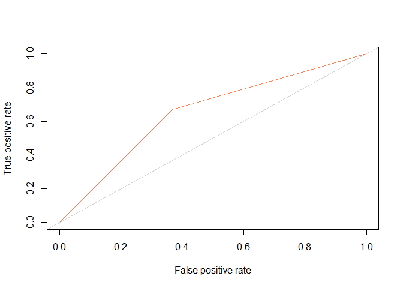

```r
pred_model2 = prediction(pred.glm,train_test$target)
AUC_2 = performance(pred_model2,"tpr","fpr")
plot(AUC_2,col="coral")
abline(0,1,col = "lightgrey")
```

And her, the one from our caret model:

```r
#pred_model2 = prediction(pred,train_test$target)
#AUC_2 = performance(pred_model2,"tpr","fpr")
#plot(AUC_2,col="coral")
#abline(0,1,col = "lightgrey")
```

I had to keep them as comments otherwise nothing would work in this report.

## Random Forest

### Simple version

```r
set.seed(4004)
RF=randomForest::randomForest(target~(.-song_title-artist-key-mode),data=Train_train,mtry=sqrt(length(Train_train)-1))
```

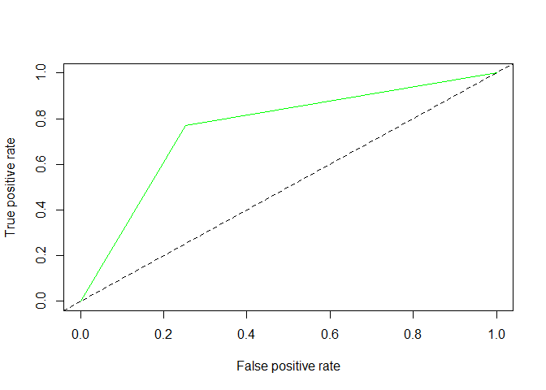

```r
predRF1=predict(RF,train_test)

predRF1=ifelse(predRF1>0.5,1,0)
Performance <- function(expected,observed){
  require(ROCR)
  score <- prediction(expected,observed)
  performance(score,"auc")
  plot(performance(score,"tpr","fpr"),col="green")
  abline(0,1,lty=8)
}
Performance(predRF1,train_test$target)
```

The total percentage of mistakes for this model is : 23.9747634 %.

We used a random forest to determine if the user will like or not the music.

### Application to the whole dataset

To have a first estimation compatible sent to kaggle, we applied this model to the whole training dataset, and predicted the values of the test dataset. Finally, we put it all in a dataframe to be sent to a .csv file. This first result was even better than anticipated earlier, with a validation rate of 79% (according to kaggle). (here, for lisibility, we only show the beginning and the end of the result dataframe)

```r
set.seed(4004)
RF2=randomForest::randomForest(target~(.-song_title-artist-key-mode),data=training_set,mtry=sqrt(length(training_set)-1))
predRF2=predict(RF2,testing_set)
predRF2=ifelse(predRF2>0.5,1,0)
result=data.frame(cbind(id=1:200,target=predRF2))
kable(result[1:5,])
```

| id | target |
| --- | --- |
| 1 | 1 |
| 2 | 1 |
| 3 | 0 |
| 4 | 0 |
| 5 | 0 |

```r
kable(result[195:200,])
```

|  | id | target |
| --- | --- | --- |
| 195 | 195 | 0 |
| 196 | 196 | 0 |
| 197 | 197 | 0 |
| 198 | 198 | 1 |
| 199 | 199 | 1 |
| 200 | 200 | 1 |

### Final version

Finally, the last twenty minutes, we were trying again and again to change our parameters to tune the randomForest. We achieved to find the following answer, with an accuracy of 80.5%

```r
set.seed(4004)

RF2=randomForest::randomForest(target~(.-song_title-artist-key-mode),data=training_set,mtry=sqrt(length(training_set)-1),ntree = 1000)
predRF2=predict(RF2,testing_set)


predRF2=ifelse(predRF2>0.5,1,0)
result=data.frame(cbind(id=1:200,target=predRF2))
#write.csv(result,file="C:/Users/anais/Documents/Esilv/S7/Machine Learning/TD/Hackaton/pred17.csv",row.names=FALSE)
```

### ROC curve

Here is the ROC curve of our final version :

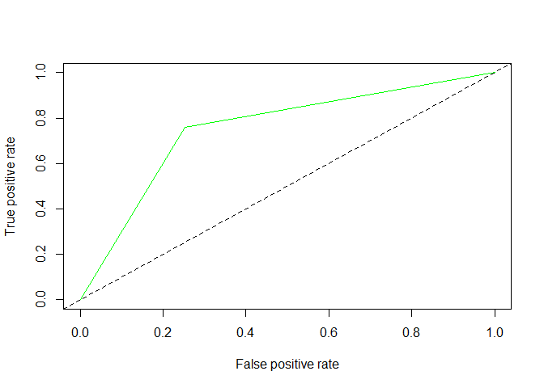

```r
RF=randomForest::randomForest(target~(.-song_title-artist-key-mode),data=Train_train,mtry=sqrt(length(Train_train)-1),ntree= 1000)
predRF1=predict(RF,train_test)

predRF1=ifelse(predRF1>0.5,1,0)
Performance(predRF1,train_test$target)
```

## Bagging

### Main code

After our first try with the random forest, we tried the bagging method :

```r
bagged <- randomForest(target ~ (.-song_title-artist-key-mode), data = Train_train, mtry=length(Train_train)-1)
predRF1=predict(bagged,train_test)

predRF1=ifelse(predRF1>0.5,1,0)
sum(ifelse(predRF1==train_test$target,0,1))/317*100
```

```
## [1] 25.55205
```

```r
RF2 <- randomForest(target~(.-song_title-artist-key-mode),data=training_set,mtry=length(training_set)-1,method="class")
predRF2=predict(RF2,testing_set)

predRF2=ifelse(predRF2>0.5,1,0)
result=data.frame(cbind(id=1:200,target=predRF2))
#write.csv(result,file="C:/Users/anais/Documents/Esilv/S7/Machine Learning/TD/Hackaton/pred4.csv",row.names=FALSE)
predRF2
```

```
##   1   2   3   4   5   6   7   8   9  10  11  12  13  14  15  16  17  18  19  20
##   1   1   0   0   1   1   1   1   0   0   1   0   0   1   1   1   0   1   1   1
##  21  22  23  24  25  26  27  28  29  30  31  32  33  34  35  36  37  38  39  40
##   1   1   0   0   1   1   1   0   1   1   0   0   1   1   0   0   1   0   0   0
##  41  42  43  44  45  46  47  48  49  50  51  52  53  54  55  56  57  58  59  60
##   0   0   1   0   1   1   0   0   1   1   1   0   0   0   0   0   0   1   0   0
##  61  62  63  64  65  66  67  68  69  70  71  72  73  74  75  76  77  78  79  80
##   1   0   1   1   0   1   1   1   1   1   1   1   1   0   1   1   0   1   0   0
##  81  82  83  84  85  86  87  88  89  90  91  92  93  94  95  96  97  98  99 100
##   1   1   1   0   0   0   0   0   0   0   1   1   1   1   0   1   0   1   0   1
## 101 102 103 104 105 106 107 108 109 110 111 112 113 114 115 116 117 118 119 120
##   0   1   1   0   1   0   1   0   0   1   0   0   1   0   0   0   0   0   0   0
## 121 122 123 124 125 126 127 128 129 130 131 132 133 134 135 136 137 138 139 140
##   1   0   0   1   1   0   0   1   1   1   1   1   1   1   1   0   0   0   1   0
## 141 142 143 144 145 146 147 148 149 150 151 152 153 154 155 156 157 158 159 160
##   1   1   1   0   0   1   0   0   1   0   1   0   1   0   0   1   1   0   0   0
## 161 162 163 164 165 166 167 168 169 170 171 172 173 174 175 176 177 178 179 180
##   1   1   0   1   1   0   1   0   0   0   1   0   1   1   1   0   0   1   0   1
## 181 182 183 184 185 186 187 188 189 190 191 192 193 194 195 196 197 198 199 200
##   1   0   0   0   0   0   1   1   0   0   1   0   1   1   0   1   0   1   1   1
```

We see here that our error is around 25.55%. We obtained an accuracy of 78.5% with this model.

### ROC curve

Here is the ROC curve of this model :

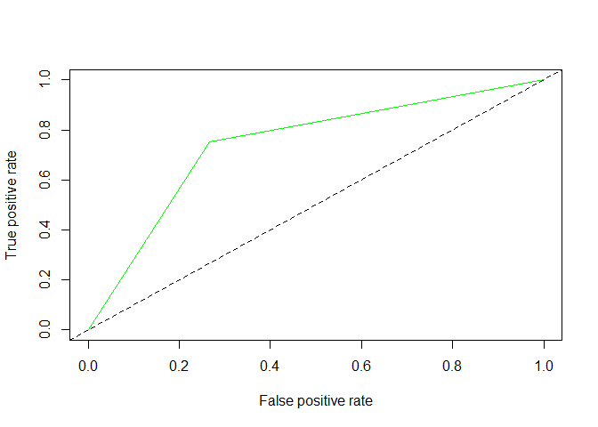

```r
Performance(predRF1,train_test$target)
```

## Boosting

### Main code

We also tried the Boosting method, since it worked well during classes.

```r
boosted <- gbm(target ~ (.-key-mode), data = Train_train[1:14], distribution = "gaussian",
                    n.trees = 5000, interaction.depth = 5, shrinkage = 0.008)
Boston_boost_predict <- predict(boosted, train_test[1:14])
```

```
## Using 5000 trees...
```

```r
predRF1=ifelse(Boston_boost_predict>0.5,1,0)
sum(ifelse(predRF1==train_test$target,0,1))/317*100
```

```
## [1] 22.08202
```

```r
boosted2 <- gbm(target ~ (.-key-mode), data = training_set[1:14], distribution = "gaussian",
               n.trees = 5000, interaction.depth = 4, shrinkage = 0.01)
Boston_boost_predict2 <- predict(boosted2, testing_set[1:13])
```

```
## Using 5000 trees...
```

```r
predRF2=ifelse(Boston_boost_predict2>0.5,1,0)
result=data.frame(cbind(id=1:200,target=predRF2))
#write.csv(result,file="C:/Users/anais/Documents/Esilv/S7/Machine Learning/TD/Hackaton/pred6.csv",row.names=FALSE)
predRF2
```

```
##   [1] 1 1 0 0 1 1 1 1 0 0 1 0 0 0 1 0 0 1 1 0 1 1 0 0 1 1 1 0 1 1 0 1 1 1 0 0 1
##  [38] 0 0 0 0 0 1 0 1 1 0 1 1 1 1 0 0 0 0 0 1 1 0 0 1 0 1 1 0 0 1 1 1 1 1 1 1 0
##  [75] 1 0 0 1 0 0 1 1 1 0 0 0 0 0 0 0 1 0 1 1 0 1 0 1 0 1 0 1 1 0 1 0 1 0 0 1 0
## [112] 0 1 0 0 1 0 0 0 0 1 0 0 1 1 0 0 1 1 1 1 1 1 1 1 0 0 0 1 0 1 1 1 0 0 1 0 0
## [149] 1 0 0 0 1 0 0 1 1 0 0 0 0 1 1 1 1 0 1 0 1 0 1 0 1 1 1 0 0 1 0 1 1 0 0 0 0
## [186] 0 0 1 0 0 1 0 1 1 0 0 0 1 1 1
```

We obtained an accuracy of 78% on Kaggle.

### ROC curve

Here is the ROC curve of the Boosting model :

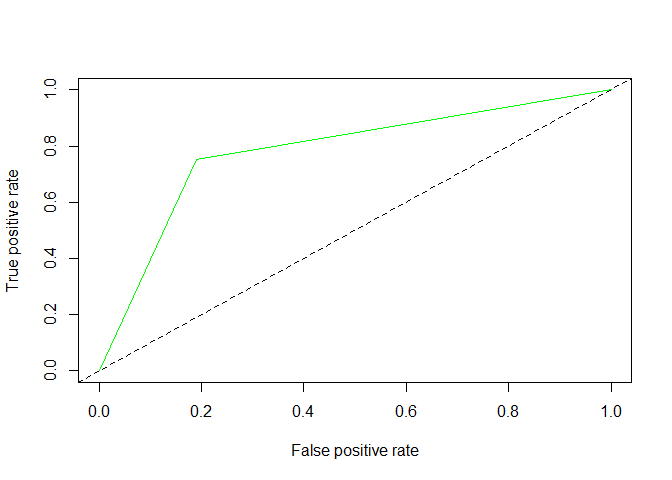

```r
Performance(predRF1,train_test$target)
```

## K-means

We also had the idea to use some unsupervised algorithms to find out if the user will like the music or not. We first thought of k-means :

```r
set.seed(4004)
km=kmeans(training_set[,c(-15,-16)],centers=2,iter.max = 20)
predKM=km$cluster-1
```

But the result was with the margin of success of 55.8062741 % which is not good enough to be compared with Random Forest. We didn’t send any test using this model.

## Hierarchical clustering

Another idea was to use hierchical clustering.

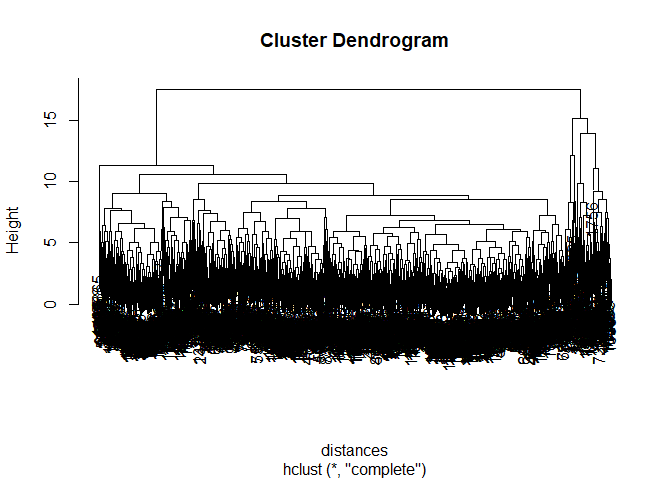

```r
set.seed(4004)
ScaledTrain=data.frame(scale(training_set[,c(-16,-15)]))
distances=dist(ScaledTrain)
dendrogram=hclust(distances,method="complete")
plot(dendrogram)
```

But the dendrograms were too complex and the results, not good enough. Indeed, the error rate for this model was of 51.5134838 %.

## EM

The final idea was to use EM, and giving it 2 clusters to find.

```r
set.seed(4004)
library(mclust)
mc=Mclust(ScaledTrain[-14],2)
testClass=ifelse(mc$classification==2,1,0)
```

But, once again, the result was barely better than sheer luck : 56.1915245%.